# Homework 2

Kirk Vanacore

9/8/2021

## Bayesian Computation in Stan and R

## Load/Setup STRAN

```r
library(rstan) # observe startup messages
options(mc.cores = parallel::detectCores()) # Use all local cores (does this work for all r packages?)
rstan_options(auto_write = TRUE) # saves stan to hard drive
Sys.setenv(TZ = "America/Toronto") # this deals with a time zone bug issue that was causes an error when running the model
```

This is an example in Section 5.5 of Gelman et al (2003), which studied coaching effects from eight schools. For simplicity, we call this example “eight schools.”

## Write STAN file

```
// saved as schools.stan
data {
  int<lower=0> J;         // number of schools
  real y[J];              // estimated treatment effects
  real<lower=0> sigma[J]; // standard error of effect estimates
}
parameters {
  real mu;                // population treatment effect
  real<lower=0> tau;      // standard deviation in treatment effects
  vector[J] eta;          // unscaled deviation from mu by school
}
transformed parameters {
  vector[J] theta = mu + tau * eta;        // school treatment effects
}
model {
  target += normal_lpdf(eta | 0, 1);       // prior log-density
  target += normal_lpdf(y | theta, sigma); // log-likelihood
}
```

Be sure that your Stan programs ends in a blank line without any characters including spaces and comments.

In this Stan program, we let theta be a transformation of mu, eta, and tau instead of declaring theta in the parameters block, which allows the sampler will run more efficiently .

### Prepare data

We can prepare the data (which typically is a named list) in R with:

```r
rm(list = ls())
schools_dat <- list(J = 9,
                    y = c(5.41,  5, 6.29,  10.95, 9.53, 7.28, 6.59, 2.72, 6.94),
                    sigma = c(0.33, 0.25, 0.2, 0.12,  0.19, 0.23, 0.24, 0.22, 0.17)) # treatment effects for each school

condition_dat <- list(J = 4,
                    y = c(7.41, 6.01, 7.21, 7.33),
                    sigma = c(0.18, 0.18, 0.13, 0.18)) # treatment effects for each school

#WHY DO WE USE THE SE? SHOULDN"T SIGMA BE THE SD (its it because the SE takes into account sample size?)
```

And we can get a fit with the following R command. Note that the argument to file = should point to where the file is on your file system unless you have put it in the working directory of R in which case the below will work.

# School Models

RESEARCH QUESTIONS: Does the postest vary between schools?

```r
fit <- stan(file = 'schools.stan', data = schools_dat)
```

[output not shown]

[output not shown]

## Output

```r
print(fit)
```

```
## Inference for Stan model: schools.
## 3 chains, each with iter=2000; warmup=1000; thin=1;
## post-warmup draws per chain=1000, total post-warmup draws=3000.
##
##           mean se_mean   sd   2.5%    25%   50%   75% 97.5% n_eff Rhat
## mu        6.79    0.05 0.97   4.96   6.17  6.73  7.42  8.85   421 1.01
## tau       2.90    0.05 0.84   1.73   2.29  2.74  3.33  4.98   301 1.01
## eta[1]   -0.50    0.02 0.36  -1.29  -0.71 -0.49 -0.26  0.15   442 1.01
## eta[2]   -0.65    0.02 0.37  -1.44  -0.87 -0.64 -0.40  0.03   425 1.01
## eta[3]   -0.18    0.02 0.34  -0.86  -0.40 -0.17  0.05  0.46   428 1.01
## eta[4]    1.54    0.03 0.54   0.56   1.16  1.51  1.92  2.62   349 1.00
## eta[5]    1.01    0.02 0.43   0.17   0.72  1.01  1.30  1.88   373 1.00
## eta[6]    0.18    0.02 0.34  -0.53  -0.06  0.20  0.41  0.85   422 1.00
## eta[7]   -0.07    0.02 0.33  -0.75  -0.30 -0.05  0.15  0.57   436 1.00
## eta[8]   -1.49    0.03 0.50  -2.59  -1.79 -1.46 -1.16 -0.55   358 1.01
## eta[9]    0.06    0.02 0.33  -0.62  -0.17  0.07  0.28  0.68   417 1.00
## theta[1]  5.43    0.01 0.33   4.79   5.21  5.44  5.66  6.08  2918 1.00
## theta[2]  5.02    0.00 0.25   4.53   4.85  5.01  5.18  5.50  3103 1.00
## theta[3]  6.30    0.00 0.20   5.90   6.16  6.30  6.44  6.69  3851 1.00
## theta[4] 10.94    0.00 0.12  10.70  10.86 10.94 11.02 11.18  2630 1.00
## theta[5]  9.51    0.00 0.19   9.15   9.39  9.51  9.64  9.87  4086 1.00
## theta[6]  7.27    0.00 0.23   6.81   7.11  7.27  7.44  7.73  3771 1.00
## theta[7]  6.59    0.00 0.25   6.10   6.42  6.58  6.75  7.08  3716 1.00
## theta[8]  2.75    0.00 0.22   2.32   2.60  2.75  2.90  3.18  4118 1.00
## theta[9]  6.93    0.00 0.17   6.61   6.82  6.94  7.04  7.25  3993 1.00
## lp__     -9.89    0.14 3.11 -16.74 -11.82 -9.53 -7.67 -4.77   469 1.00
##
## Samples were drawn using NUTS(diag_e) at Sat Sep 25 06:39:27 2021.
## For each parameter, n_eff is a crude measure of effective sample size,
## and Rhat is the potential scale reduction factor on split chains (at
## convergence, Rhat=1).
```

## Plot Paramteres

```
## ci_level: 0.8 (80% intervals)
```

```
## outer_level: 0.95 (95% intervals)
```

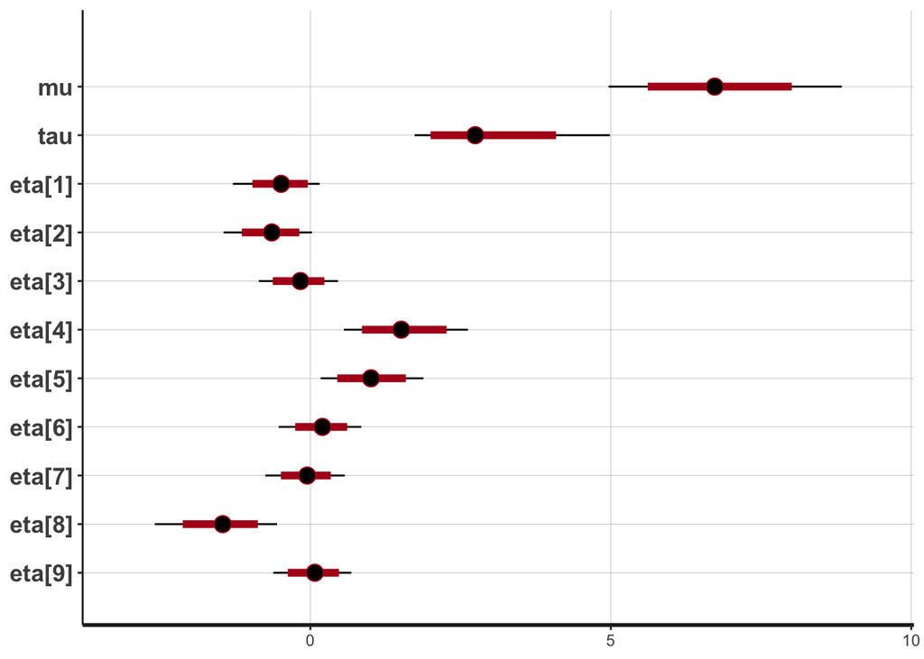

```r
plot(fit, pars = c("mu",
                   "tau",
                   "eta[1]", # differences between the overall mean and the cluster mean
                   "eta[2]",
                   "eta[3]",
                   "eta[4]",
                   "eta[5]",
                   "eta[6]",
                   "eta[7]",
                   "eta[8]",
                   "eta[9]"
                   ))
```

yi ~ N(theta1i, sigmai) theta ~ N(mu, tau)

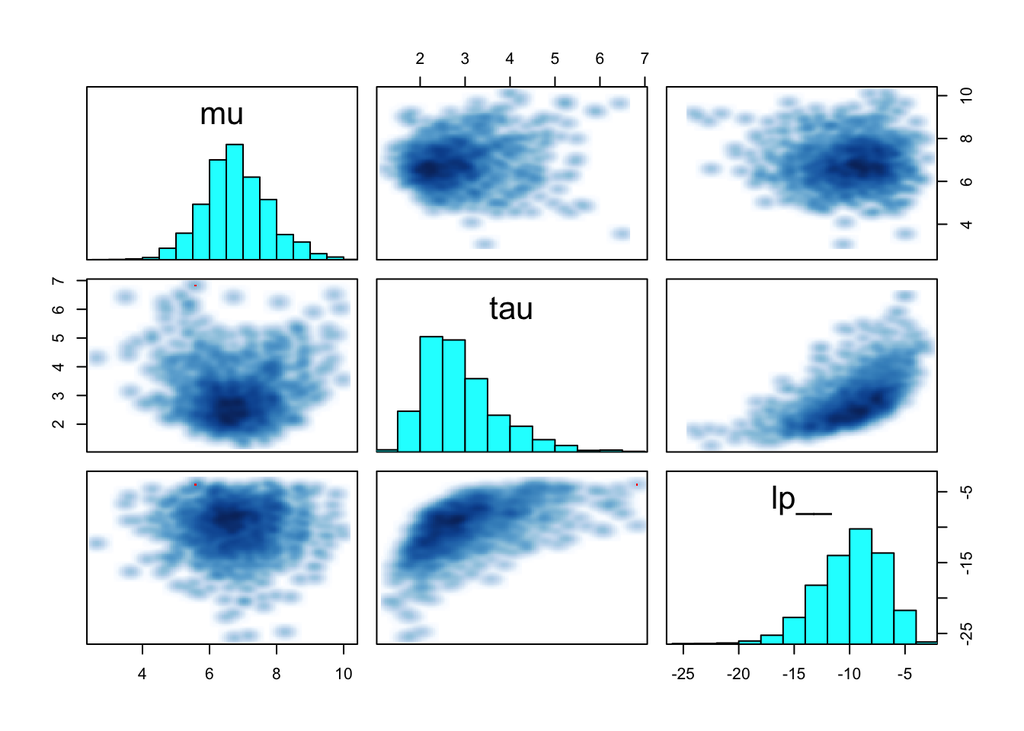

```r
pairs(fit, pars = c("mu", # means
                    "tau", # between cluster variance
                    "lp__" #?
                    ))
```

# Condition Models

RESEARCH QUESTIONS: Does the posttest vary between Conditions?

```r
fit2 <- stan(file = 'schools.stan', data = condition_dat)
```

[output not shown]

[output not shown]

## Plot Paramteres

```
## ci_level: 0.8 (80% intervals)
```

```
## outer_level: 0.95 (95% intervals)
```

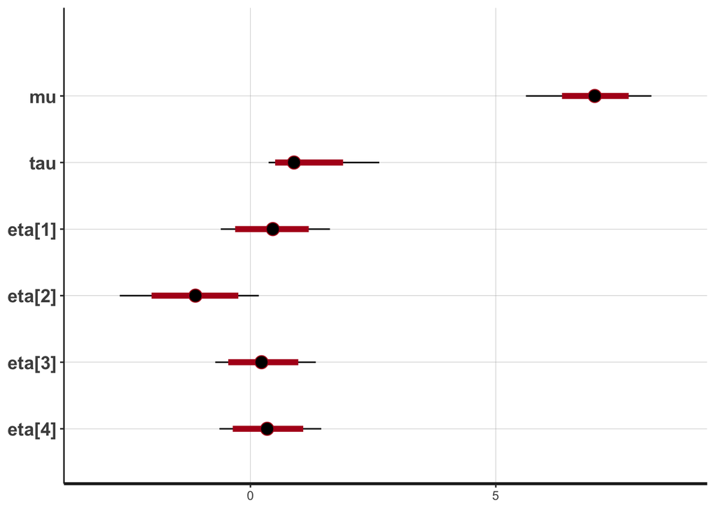

```r
plot(fit2, pars = c("mu",
                   "tau",
                   "eta[1]",
                   "eta[2]",
                   "eta[3]",
                   "eta[4]"
                   ))
```

[figure not shown]

```r
pairs(fit, pars = c("mu", # mean
                    "tau", # between cluster variance
                    "lp__")) # some version of the posteior
```

# other code

```r
la <- extract(fit, permuted = TRUE) # return a list of arrays
mu <- la$mu

### return an array of three dimensions: iterations, chains, parameters
a <- extract(fit, permuted = FALSE)

### use S3 functions on stanfit objects
a2 <- as.array(fit)
m <- as.matrix(fit)
d <- as.data.frame(fit)
```